# Introduction to statistical analysis using R

Dr. Wan Nor Arifin

Updated: 15 December 2025

# 1 Data management

## 1.1 Reading data

### 1.1.1 Basic file:

**.csv (Spreadsheet/Excel)**

```r
data = read.csv("cholest.csv")
```

### 1.1.2 Other formats:

**.sav (SPSS) and .dta (STATA)**

Require `foreign` package:

```r
library(foreign)
```

Read SPSS file, .sav,

```r
data = read.spss("cholest.sav", to.data.frame = TRUE)
```

Read STATA files, .dta,

```r
data = read.dta("cholest.dta")
```

## 1.2 Viewing data

Let’s continue using `cholest.sav` dataset,

```r
data = read.spss("cholest.sav", to.data.frame = TRUE)
```

View full data by,

```r
data
```

```
#>    chol age exercise    sex categ
#> 1   6.5  38        6   male Grp A
#> 2   6.6  35        5   male Grp A
#> 3   6.8  39        6   male Grp A
#> 4   6.8  36        5   male Grp A
#> 5   6.9  31        4   male Grp A
#> 6   7.0  38        4   male Grp A
#> 7   7.0  33        5   male Grp A
#> 8   7.2  36        5   male Grp A
#> 9   7.2  40        4   male Grp A
#> 10  7.2  34        6   male Grp A
#> 11  7.3  38        6   male Grp A
#> 12  7.3  40        5   male Grp A
#> 13  7.3  40        4   male Grp A
#> 14  7.3  28        5   male Grp A
```

[output cut: 66 more lines]

or by,

```r
View(data)
```

View the first and last six observations,

```r
head(data)
```

```
#>   chol age exercise  sex categ
#> 1  6.5  38        6 male Grp A
#> 2  6.6  35        5 male Grp A
#> 3  6.8  39        6 male Grp A
#> 4  6.8  36        5 male Grp A
#> 5  6.9  31        4 male Grp A
#> 6  7.0  38        4 male Grp A
```

```r
tail(data)
```

```
#>    chol age exercise    sex categ
#> 75  9.4  45        4 female Grp C
#> 76  9.5  52        4 female Grp C
#> 77  9.6  35        4 female Grp C
#> 78  9.8  43        3 female Grp C
#> 79  9.9  47        3 female Grp C
#> 80 10.0  44        3 female Grp C
```

These are very useful for very long datasets, whenever we just want to get some idea about the data layout.

Basic information about the data,

```r
str(data)
```

```
#> 'data.frame':    80 obs. of  5 variables:
#>  $ chol    : num  6.5 6.6 6.8 6.8 6.9 7 7 7.2 7.2 7.2 ...
#>  $ age     : num  38 35 39 36 31 38 33 36 40 34 ...
#>  $ exercise: num  6 5 6 5 4 4 5 5 4 6 ...
#>  $ sex     : Factor w/ 2 levels "female","male": 2 2 2 2 2 2 2 2 2 2 ...
#>  $ categ   : Factor w/ 3 levels "Grp A","Grp B",..: 1 1 1 1 1 1 1 1 1 1 ...
#>  - attr(*, "variable.labels")= Named chr [1:5] "cholesterol in mmol/L" "age in year" "duration of exercise (hours/week)" "" ...
#>   ..- attr(*, "names")= chr [1:5] "chol" "age" "exercise" "sex" ...
#>  - attr(*, "codepage")= int 65001
```

Most important, from this information

`'data.frame': 80 obs. of 5 variables`

we know that we have a data frame, with 80 observations and five variables. The names of the variables are listed in the output. ## Selecting parts of data Select a variable (column),

```r
data$age
```

```
#>  [1] 38 35 39 36 31 38 33 36 40 34 38 40 40 28 37 38 49 29 40 38 34 46 42 38 32
#> [26] 43 42 40 38 39 39 39 35 38 40 38 45 36 31 34 44 35 40 37 33 46 42 40 45 42
#> [51] 45 38 34 44 39 38 39 47 41 44 30 48 47 42 42 49 31 38 38 48 34 45 45 36 45
#> [76] 52 35 43 47 44
```

or

```r
data[ , "age"]
```

```
#>  [1] 38 35 39 36 31 38 33 36 40 34 38 40 40 28 37 38 49 29 40 38 34 46 42 38 32
#> [26] 43 42 40 38 39 39 39 35 38 40 38 45 36 31 34 44 35 40 37 33 46 42 40 45 42
#> [51] 45 38 34 44 39 38 39 47 41 44 30 48 47 42 42 49 31 38 38 48 34 45 45 36 45
#> [76] 52 35 43 47 44
```

or by column number

```r
data[ , 2]
```

```
#>  [1] 38 35 39 36 31 38 33 36 40 34 38 40 40 28 37 38 49 29 40 38 34 46 42 38 32
#> [26] 43 42 40 38 39 39 39 35 38 40 38 45 36 31 34 44 35 40 37 33 46 42 40 45 42
#> [51] 45 38 34 44 39 38 39 47 41 44 30 48 47 42 42 49 31 38 38 48 34 45 45 36 45
#> [76] 52 35 43 47 44
```

Select observations (rows),

```r
data[10:20, ]
```

```
#>    chol age exercise  sex categ
#> 10  7.2  34        6 male Grp A
#> 11  7.3  38        6 male Grp A
#> 12  7.3  40        5 male Grp A
#> 13  7.3  40        4 male Grp A
#> 14  7.3  28        5 male Grp A
#> 15  7.3  37        5 male Grp A
#> 16  7.4  38        4 male Grp A
#> 17  7.4  49        5 male Grp A
#> 18  7.4  29        5 male Grp A
#> 19  7.5  40        3 male Grp A
#> 20  7.6  38        5 male Grp A
```

Select observations and variables,

```r
data[10:20, c("age", "categ")]
```

```
#>    age categ
#> 10  34 Grp A
#> 11  38 Grp A
#> 12  40 Grp A
#> 13  40 Grp A
#> 14  28 Grp A
#> 15  37 Grp A
#> 16  38 Grp A
#> 17  49 Grp A
#> 18  29 Grp A
#> 19  40 Grp A
#> 20  38 Grp A
```

or

```r
data[10:20, c(2, 5)]
```

```
#>    age categ
#> 10  34 Grp A
#> 11  38 Grp A
#> 12  40 Grp A
#> 13  40 Grp A
#> 14  28 Grp A
#> 15  37 Grp A
#> 16  38 Grp A
#> 17  49 Grp A
#> 18  29 Grp A
#> 19  40 Grp A
#> 20  38 Grp A
```

```r
data[c(1:10, 20:30), c("age", "categ")]
```

```
#>    age categ
#> 1   38 Grp A
#> 2   35 Grp A
#> 3   39 Grp A
#> 4   36 Grp A
#> 5   31 Grp A
#> 6   38 Grp A
#> 7   33 Grp A
#> 8   36 Grp A
#> 9   40 Grp A
#> 10  34 Grp A
#> 20  38 Grp A
#> 21  34 Grp A
#> 22  46 Grp A
#> 23  42 Grp A
#> 24  38 Grp A
#> 25  32 Grp A
#> 26  43 Grp B
#> 27  42 Grp B
#> 28  40 Grp B
#> 29  38 Grp B
#> 30  39 Grp B
```

More advanced row selection is done using `subset(data, row, column)` function in R. `>` (more than) is called condition. You can try with the rest of conditions: `<` (less than), `>=` (more than or equal), `<=` (less than or equal), `==` (equal), `!=` (not equal).

```r
subset(data, age > 35, c(age, categ))
```

```
#>    age categ
#> 1   38 Grp A
#> 3   39 Grp A
#> 4   36 Grp A
#> 6   38 Grp A
#> 8   36 Grp A
#> 9   40 Grp A
#> 11  38 Grp A
#> 12  40 Grp A
#> 13  40 Grp A
#> 15  37 Grp A
#> 16  38 Grp A
#> 17  49 Grp A
#> 19  40 Grp A
#> 20  38 Grp A
```

[output cut: 48 more lines]

You can also specify a combination of two or more conditions using `&` (and) and `|` (or).

```r
subset(data, age > 35 & sex == "female", c(age, sex, categ))
```

```
#>    age    sex categ
#> 41  44 female Grp B
#> 43  40 female Grp B
#> 44  37 female Grp B
#> 46  46 female Grp B
#> 47  42 female Grp B
#> 48  40 female Grp B
#> 49  45 female Grp B
#> 50  42 female Grp B
#> 51  45 female Grp B
#> 52  38 female Grp B
#> 54  44 female Grp B
#> 55  39 female Grp B
#> 56  38 female Grp B
#> 57  39 female Grp B
```

[output cut: 19 more lines]

*I covered for builtin functions. Keep in mind that you may also use `dplyr()` or `tidyverse` styles. This can be easily asked from ChatGPT/Gemini.

## 1.3 Modifying data

### 1.3.1 Creating new variables

Create age in month,

```r
data$age_month = data$age * 12
data$age_month
```

```
#>  [1] 456 420 468 432 372 456 396 432 480 408 456 480 480 336 444 456 588 348 480
#> [20] 456 408 552 504 456 384 516 504 480 456 468 468 468 420 456 480 456 540 432
#> [39] 372 408 528 420 480 444 396 552 504 480 540 504 540 456 408 528 468 456 468
#> [58] 564 492 528 360 576 564 504 504 588 372 456 456 576 408 540 540 432 540 624
#> [77] 420 516 564 528
```

### 1.3.2 Recoding variables

Histogram of `age`,

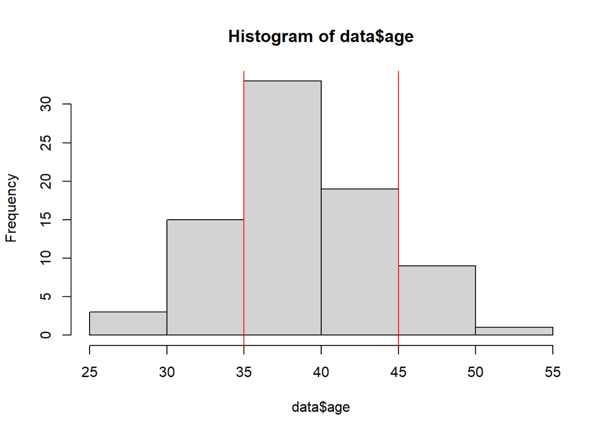

```r
hist(data$age)
abline(v = 35, col = "red")
abline(v = 45, col = "red")
```

We decide to cut at 35 and 45 years old,

```r
data$age_cat = cut(data$age, breaks = c(-Inf, 35, 45, Inf),
                   labels = c("<35", "35-45", ">45"))
levels(data$age_cat)  # view the newly created categories/levels
```

```
#> [1] "<35"   "35-45" ">45"
```

```r
table(data$age_cat)  # view counts per categories
```

```
#>
#>   <35 35-45   >45
#>    18    52    10
```

We need `car` package to use `recode()` function,

```r
library(car)
data$age_cat1 = recode(data$age_cat,
                       "c('35-45', '>45') = '35 & above'")
levels(data$age_cat1)
```

```
#> [1] "<35"        "35 & above"
```

```r
table(data$age_cat1)
```

```
#>
#>        <35 35 & above
#>         18         62
```

Pay attention to the use of `" "` and `' '` in `recode()`.

# 2 Descriptive Statistics

We again use `cholest.sav` dataset. Now we give it a proper object name `cholest`,

```r
library(foreign)
cholest = read.spss("cholest.sav", to.data.frame = T)
str(cholest)
```

```
#> 'data.frame':    80 obs. of  5 variables:
#>  $ chol    : num  6.5 6.6 6.8 6.8 6.9 7 7 7.2 7.2 7.2 ...
#>  $ age     : num  38 35 39 36 31 38 33 36 40 34 ...
#>  $ exercise: num  6 5 6 5 4 4 5 5 4 6 ...
#>  $ sex     : Factor w/ 2 levels "female","male": 2 2 2 2 2 2 2 2 2 2 ...
#>  $ categ   : Factor w/ 3 levels "Grp A","Grp B",..: 1 1 1 1 1 1 1 1 1 1 ...
#>  - attr(*, "variable.labels")= Named chr [1:5] "cholesterol in mmol/L" "age in year" "duration of exercise (hours/week)" "" ...
#>   ..- attr(*, "names")= chr [1:5] "chol" "age" "exercise" "sex" ...
#>  - attr(*, "codepage")= int 65001
```

In general, simple descriptive statistics can be obtained using `summary()` function,

```r
summary(cholest)
```

```
#>       chol            age           exercise         sex       categ
#>  Min.   : 6.50   Min.   :28.00   Min.   :2.000   female:40   Grp A:25
#>  1st Qu.: 7.60   1st Qu.:36.00   1st Qu.:4.000   male  :40   Grp B:33
#>  Median : 8.30   Median :39.00   Median :4.000               Grp C:22
#>  Mean   : 8.23   Mean   :39.48   Mean   :4.225
#>  3rd Qu.: 8.80   3rd Qu.:43.25   3rd Qu.:5.000
#>  Max.   :10.00   Max.   :52.00   Max.   :6.000
```

The results depend on the variable type. ## Central tendency and dispersion For numerical variables, we can obtain the measures of central tendency (mean and median) and dispersion (standard deviation, SD and interquartile range, IQR). Now we obtain in pairs of mean (SD) and median (IQR), Mean,

```r
mean(cholest$chol)
```

```
#> [1] 8.23
```

```r
mean(cholest$age)
```

```
#> [1] 39.475
```

Standard deviation, SD,

```r
sd(cholest$chol)
```

```
#> [1] 0.8386849
```

```r
sd(cholest$age)
```

```
#> [1] 5.128661
```

Median,

```r
median(cholest$chol)
```

```
#> [1] 8.3
```

```r
median(cholest$age)
```

```
#> [1] 39
```

and interquartile range, IQR,

```r
IQR(cholest$chol)
```

```
#> [1] 1.2
```

```r
IQR(cholest$age)
```

```
#> [1] 7.25
```

*Try exploring `psych` package for descriptive statistics. ## Proportions For categorical variables, we want to obtain the count per group, proportions and percentages.

The count per group using `table()` function (we can also obtain the counts from `summary()` function as done before),

```r
tab_sex = table(cholest$sex)
tab_categ = table(cholest$categ)
tab_sex
```

```
#>
#> female   male
#>     40     40
```

```r
tab_categ
```

```
#>
#> Grp A Grp B Grp C
#>    25    33    22
```

The proportions,

```r
prop.table(tab_sex)
```

```
#>
#> female   male
#>    0.5    0.5
```

```r
prop.table(tab_categ)
```

```
#>
#>  Grp A  Grp B  Grp C
#> 0.3125 0.4125 0.2750
```

and to obtain the percentages, we multiply the proportions by 100,

```r
prop.table(tab_sex)*100
```

```
#>
#> female   male
#>     50     50
```

```r
prop.table(tab_categ)*100
```

```
#>
#> Grp A Grp B Grp C
#> 31.25 41.25 27.50
```

## 2.1 Statistics by groups

For numerical variables, we can obtain the statistics by groups (the categorical variables) using `by()` function. The syntax is `by(numerical_variable, categorical_variable, function)`.

Mean and SD for `chol` by `sex`,

```r
by(cholest$chol, cholest$sex, mean)
```

```
#> cholest$sex: female
#> [1] 8.9275
#> ------------------------------------------------------------
#> cholest$sex: male
#> [1] 7.5325
```

```r
by(cholest$chol, cholest$sex, sd)
```

```
#> cholest$sex: female
#> [1] 0.4551627
#> ------------------------------------------------------------
#> cholest$sex: male
#> [1] 0.4687066
```

## 2.2 Cross-tabulation

For categorical variables, it is important to be able to perform cross-tabulation to explore the count per cells for each combination of groups. Again, we use `table()` function.

For `sex` and `categ`, we obtain the basic cross-tabulation,

```r
tab_sex_categ = table(Gender = cholest$sex, Category = cholest$categ)
tab_sex_categ
```

```
#>         Category
#> Gender   Grp A Grp B Grp C
#>   female     0    18    22
#>   male      25    15     0
```

Notice we can give headers (“Gender” and “Category”) to groups in the table as shown above.

We can also easily obtain the proportions and percentages,

```r
prop_sex_categ = prop.table(tab_sex_categ)
prop_sex_categ
```

```
#>         Category
#> Gender    Grp A  Grp B  Grp C
#>   female 0.0000 0.2250 0.2750
#>   male   0.3125 0.1875 0.0000
```

```r
per_sex_categ = prop.table(tab_sex_categ)*100
per_sex_categ
```

```
#>         Category
#> Gender   Grp A Grp B Grp C
#>   female  0.00 22.50 27.50
#>   male   31.25 18.75  0.00
```

and add the marginal counts,

```r
margin_sex_categ = addmargins(tab_sex_categ)
margin_sex_categ
```

```
#>         Category
#> Gender   Grp A Grp B Grp C Sum
#>   female     0    18    22  40
#>   male      25    15     0  40
#>   Sum       25    33    22  80
```

and view the proportions and percentages again, including that of the marginal counts,

```r
addmargins(prop_sex_categ)
```

```
#>         Category
#> Gender    Grp A  Grp B  Grp C    Sum
#>   female 0.0000 0.2250 0.2750 0.5000
#>   male   0.3125 0.1875 0.0000 0.5000
#>   Sum    0.3125 0.4125 0.2750 1.0000
```

```r
addmargins(per_sex_categ)
```

```
#>         Category
#> Gender    Grp A  Grp B  Grp C    Sum
#>   female   0.00  22.50  27.50  50.00
#>   male    31.25  18.75   0.00  50.00
#>   Sum     31.25  41.25  27.50 100.00
```

# 3 Graphical Exploration of Data

## 3.1 Plotting using `lattice` package

We are going to use `lattice` package for plotting the plots. It creates nice plots in R and easy to explore multivariate data (i.e. many variables) and comparing plots by groups.

Load `lattice` package,

```r
library(lattice)
```

## 3.2 Histogram

We again use `cholest.sav` dataset. We give it `cholest` object name,

```r
library(foreign)
cholest = read.spss("cholest.sav", to.data.frame = TRUE)
```

and view the basic information of the dataset,

```r
str(cholest)
```

```
#> 'data.frame':    80 obs. of  5 variables:
#>  $ chol    : num  6.5 6.6 6.8 6.8 6.9 7 7 7.2 7.2 7.2 ...
#>  $ age     : num  38 35 39 36 31 38 33 36 40 34 ...
#>  $ exercise: num  6 5 6 5 4 4 5 5 4 6 ...
#>  $ sex     : Factor w/ 2 levels "female","male": 2 2 2 2 2 2 2 2 2 2 ...
#>  $ categ   : Factor w/ 3 levels "Grp A","Grp B",..: 1 1 1 1 1 1 1 1 1 1 ...
#>  - attr(*, "variable.labels")= Named chr [1:5] "cholesterol in mmol/L" "age in year" "duration of exercise (hours/week)" "" ...
#>   ..- attr(*, "names")= chr [1:5] "chol" "age" "exercise" "sex" ...
#>  - attr(*, "codepage")= int 65001
```

```r
head(cholest)
```

```
#>   chol age exercise  sex categ
#> 1  6.5  38        6 male Grp A
#> 2  6.6  35        5 male Grp A
#> 3  6.8  39        6 male Grp A
#> 4  6.8  36        5 male Grp A
#> 5  6.9  31        4 male Grp A
#> 6  7.0  38        4 male Grp A
```

### 3.2.1 Histogram

Plot the histogram for `chol`,

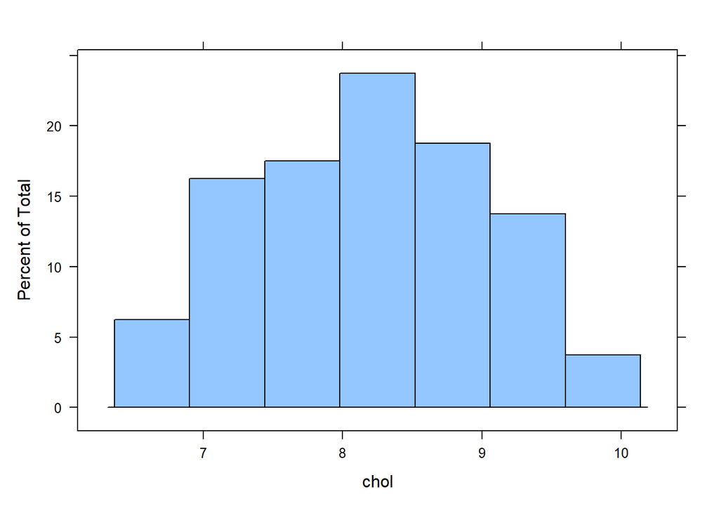

```r
histogram(~ chol, data = cholest)
```

Then plot the histogram for `chol` by `sex` and `categ` groups,

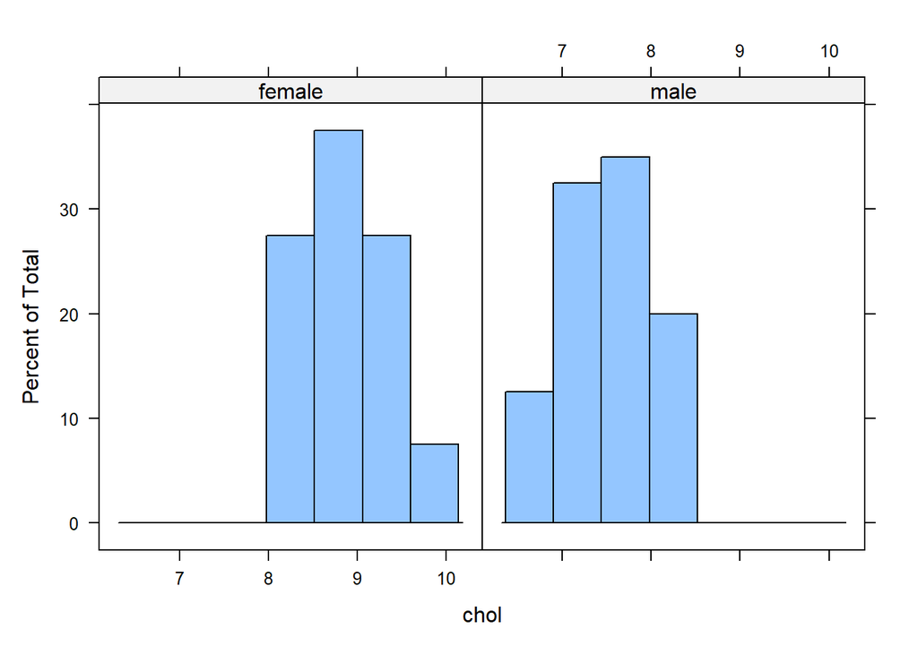

```r
histogram(~ chol | sex, data = cholest)
```

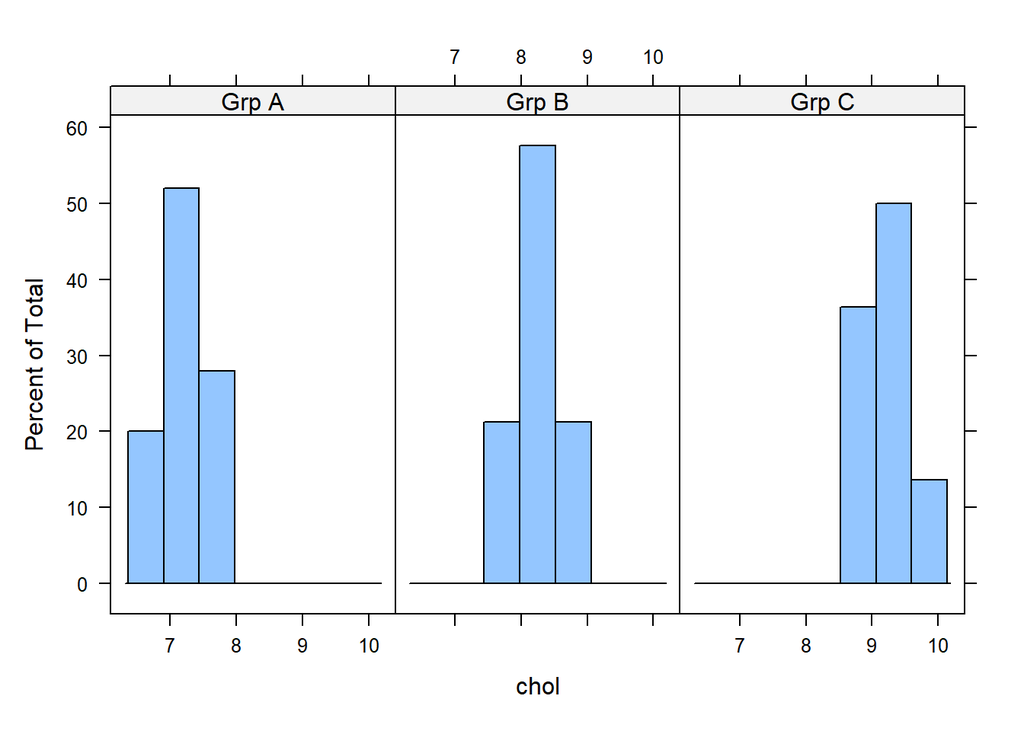

```r
histogram(~ chol | categ, data = cholest)
```

To make the comparison easier, we can adjust the layout,

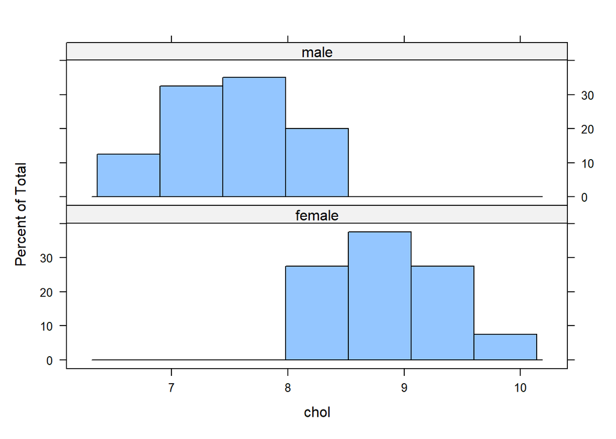

```r
histogram(~ chol | sex, data = cholest, layout = c(1, 2))
```

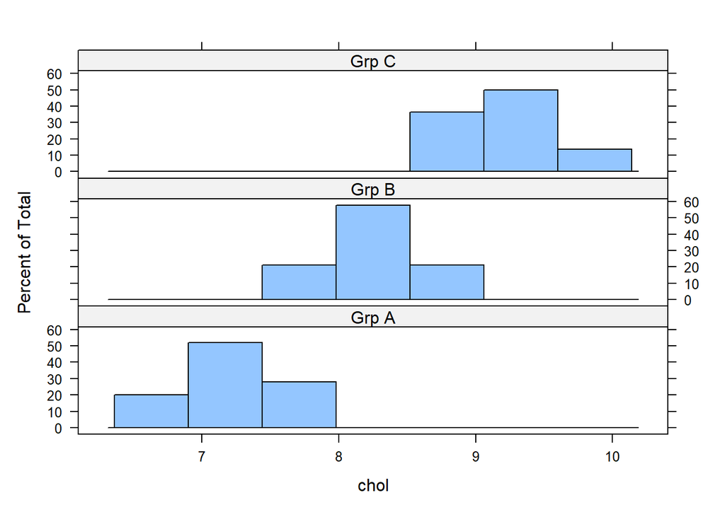

```r
histogram(~ chol | categ, data = cholest, layout = c(1, 3))
```

e.g. `layout = c(1, 2)` means 1 column (over the x-axis) and 2 rows (along the y-axis).

## 3.3 Box-and-whisker plot

Plot the box-and-whisker plot for `chol`,

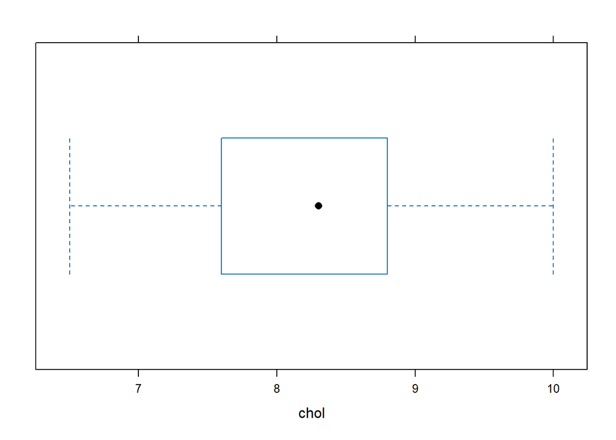

```r
bwplot(~ chol, data = cholest)
```

Then plot the box-and-whisker plot for `chol` by `sex` and `categ` groups,

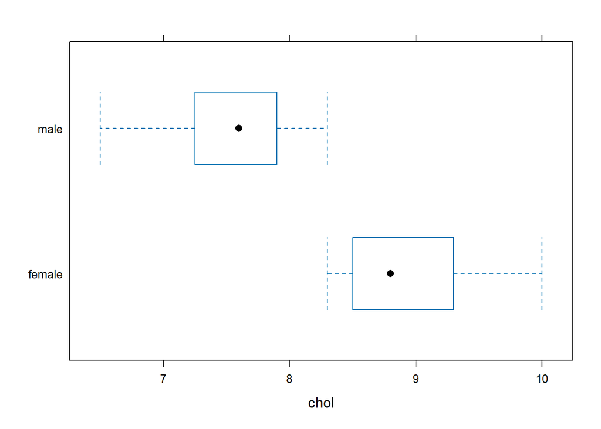

```r
bwplot(sex ~ chol, data = cholest)
```

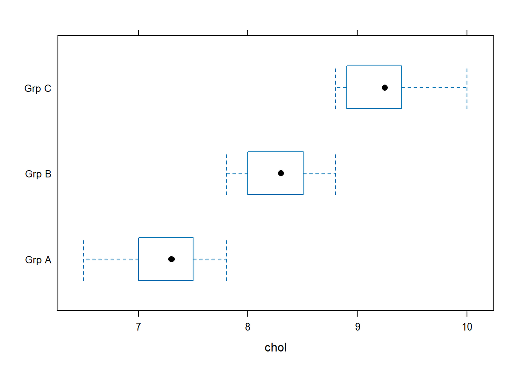

```r
bwplot(categ ~ chol, data = cholest)
```

Notice the grouping is specified before `~` sign, which set `sex` and `categ` on y-axis. The grouping can also be specified on x-axis for nicer-looking plots,

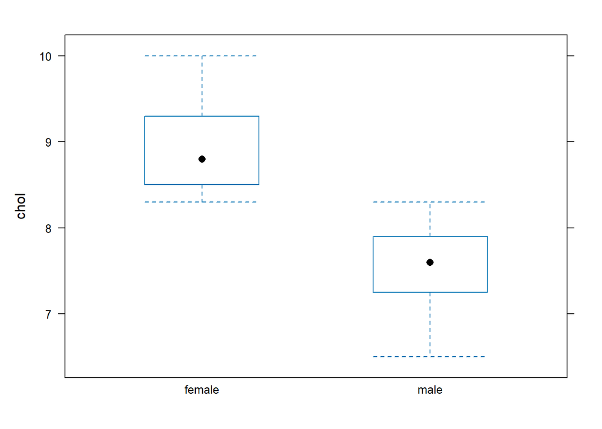

```r
bwplot(chol ~ sex, data = cholest)
```

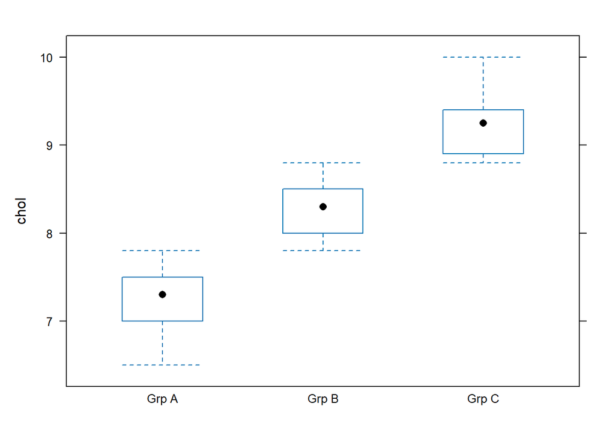

```r
bwplot(chol ~ categ, data = cholest)
```

## 3.4 Bar chart

For categorical variables, we can plot bar charts. But, first we need the count per group for the categorical variables,

```r
table_sex = table(cholest$sex)
table_sex
```

```
#>
#> female   male
#>     40     40
```

```r
table_categ = table(cholest$categ)
table_categ
```

```
#>
#> Grp A Grp B Grp C
#>    25    33    22
```

Then using the counts, we can plot the charts,

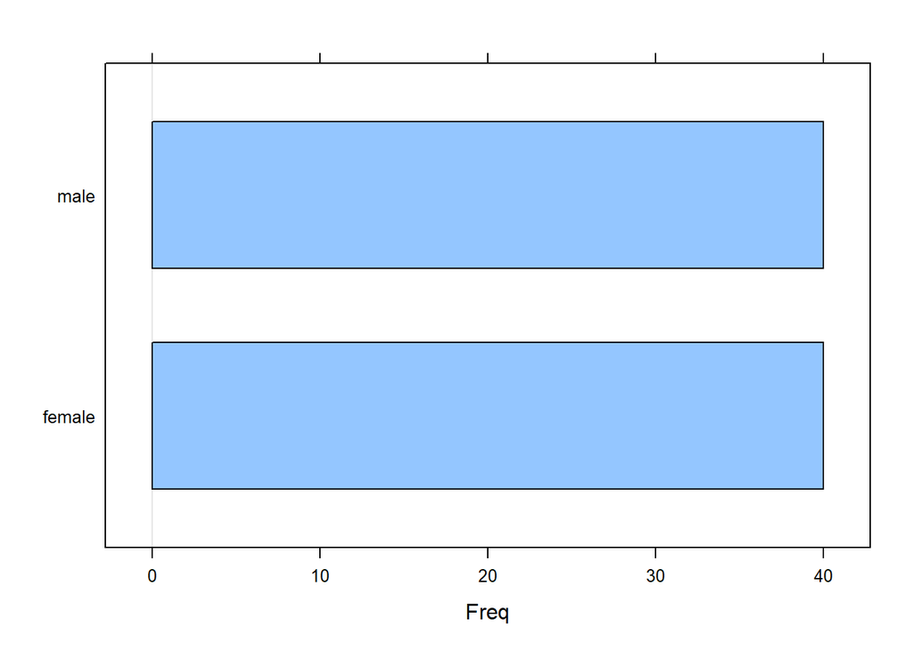

```r
barchart(table_sex)
```

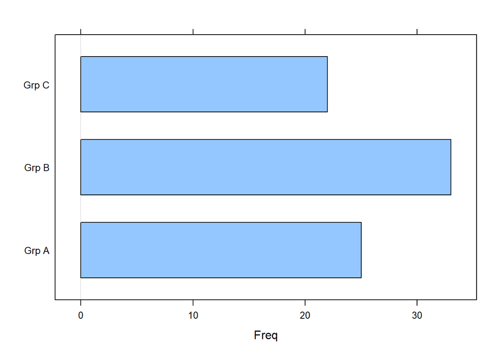

```r
barchart(table_categ)
```

For a more flexible chart setting, convert the table to a data frame, let say for `table_categ`

```r
df_categ = as.data.frame(table_categ)
colnames(df_categ) = c("Category", "Count")  # set the column names
df_categ
```

```
#>   Category Count
#> 1    Grp A    25
#> 2    Grp B    33
#> 3    Grp C    22
```

Then, we can plot with `Category` as x-axis,

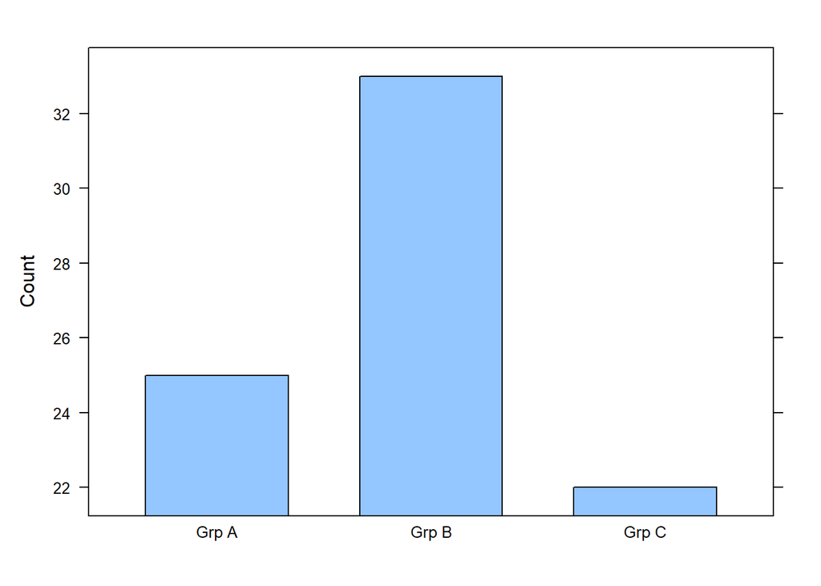

```r
barchart(Count ~ Category, data = df_categ)
```

We can also plot cross-tabulated groups (e.g. `sex vs categ`). First, properly prepare the data frame,

```r
table_sex_categ = table(cholest$sex, cholest$categ)  # obtain the count
df_sex_categ = as.data.frame(table_sex_categ)  # save as data frame
colnames(df_sex_categ) = c("Sex", "Category", "Count")  # give proper names
```

Then, plot the barcharts,

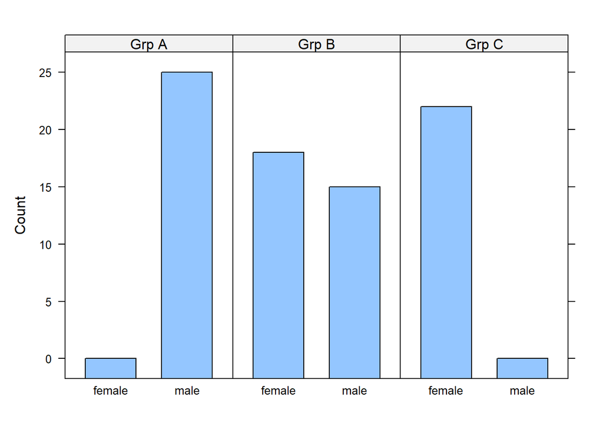

```r
barchart(Count ~ Sex | Category, df_sex_categ, layout = c(3, 1))
```

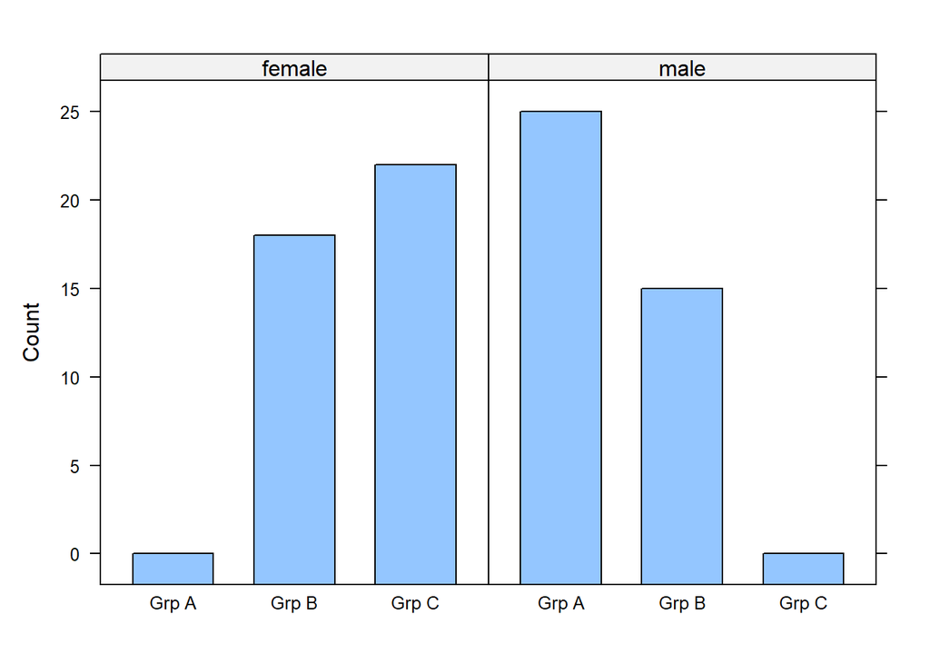

```r
barchart(Count ~ Category | Sex, df_sex_categ, layout = c(2, 1))
```

## 3.5 Scatter plot

Plot a scatter plot to explore the relationship between cholestrol and age (y-axis `chol` vs x-axis `age`),

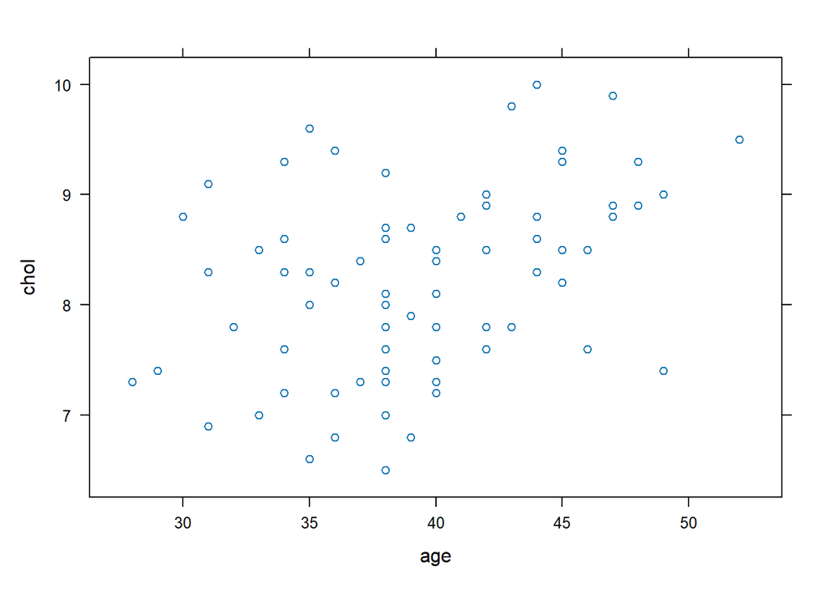

```r
xyplot(chol ~ age, data = cholest)
```

We can also explore the relationship by groups,

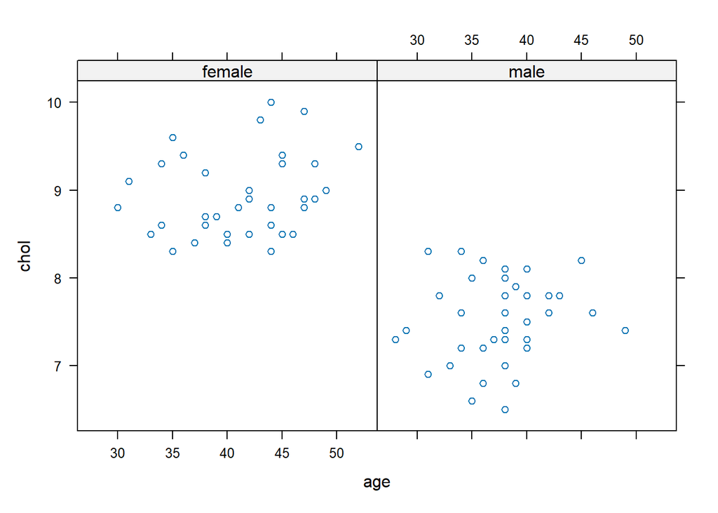

```r
xyplot(chol ~ age | sex, data = cholest)
```

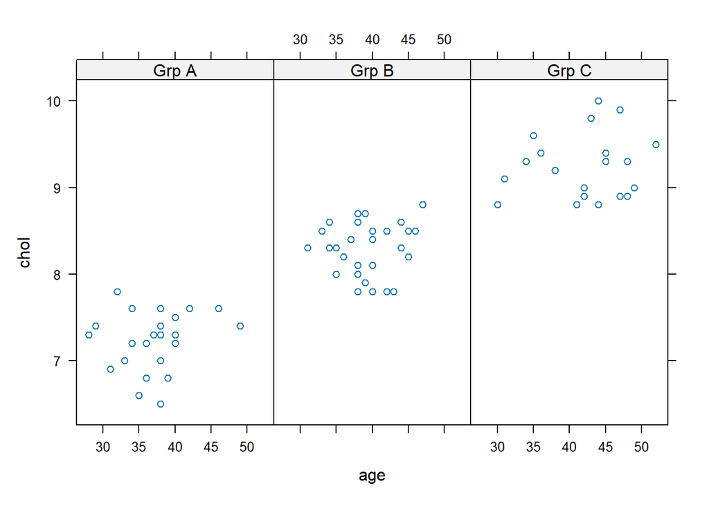

```r
xyplot(chol ~ age | categ, data = cholest, layout = c(3,1))
```

There seem to be some patterns of cholestrol levels by groups.